# Assignment 1

Folorunsho Atanda

2023-09-04

Objective: The objective of this assignment is to take data set and make a subset of it. For my task I took the data set that shows the approval rating of Trump and Biden based on how they handle the covid pandemic

```r
## import data.table library
library(data.table)
## import ggplot library
library(ggplot2)
```

```r
## import covid approval poll csv
url <- "https://raw.githubusercontent.com/folushoa/Data-Science/Data-607/covid_approval_polls.csv"
covid_approval_poll <- fread(input = url, sep = ",", header = TRUE)
```

```r
## subset of covid approval status focusing on Trump
trump_approval_poll <- subset(covid_approval_poll,
                              subject == "Trump" & party == "all",
                              select = c(start_date, end_date, approve,
                                         disapprove, sample_size))

## subset of covid approval status focusing on Biden
biden_approval_poll <- subset(covid_approval_poll,
                              subject == "Biden" & party == "all",
                              select = c(start_date, end_date, approve,
                                         disapprove, sample_size))
```

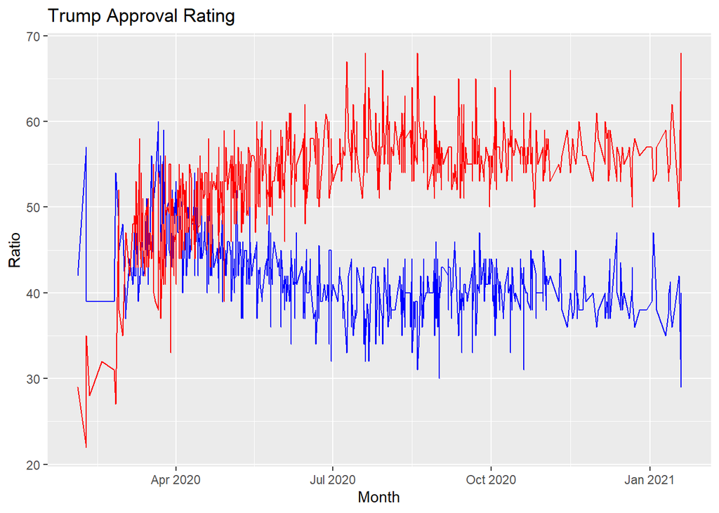

```r
## plot of Trump approval and disapproval
trump_poll_plot <- ggplot(data = trump_approval_poll, aes(x = end_date,
                   y = approve)) + geom_line(color = 'blue') + labs(x = "Month",
                   y = "Ratio", title = "Trump Approval Rating")
trump_poll_plot <- trump_poll_plot + geom_line(aes(x = end_date,
                   y = disapprove), color = 'red')
trump_poll_plot <- trump_poll_plot +
  scale_color_manual(name = "Approval Status", breaks = c('Approve', 'Disapprove'),
  values = c('Approve' =  'blue', 'Disapprove' = 'red'))
trump_poll_plot
```

Observation: Examining the preceding graph illustrating Trump’s approval ratings (indicated by the color blue) and disapproval ratings (indicated by the color red), it becomes evident that at the onset of the pandemic, Trump enjoyed a favorable approval rating. However, this dynamic shifted in April, as we observe a notable rise in his disapproval ratings.

When President Biden assumed office in January 2021, Trump’s disapproval rating surpassed his approval rating.

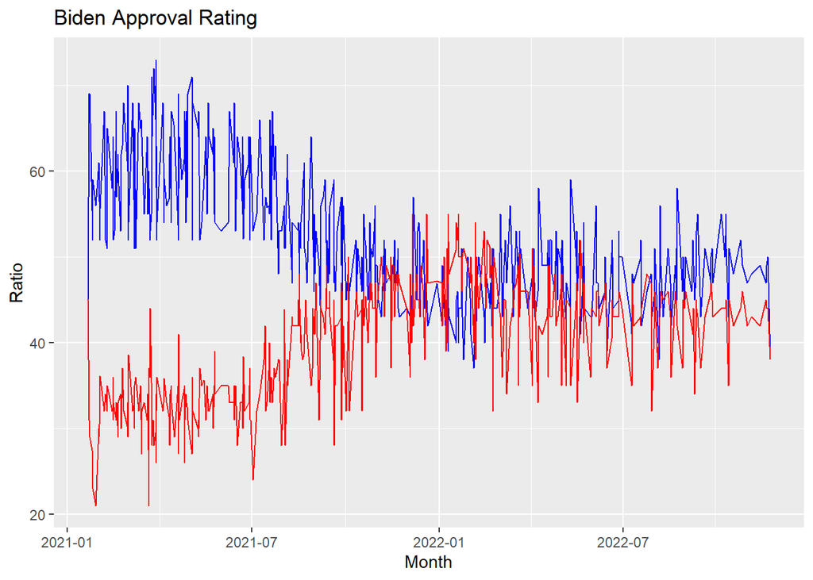

```r
## plot of Biden approval and disapproval
biden_poll_plot <- ggplot(data = biden_approval_poll, aes(x = end_date,
                   y = approve)) + geom_line(color = 'blue') + labs(x = "Month",
                   y = "Ratio", title = "Biden Approval Rating")
biden_poll_plot <- biden_poll_plot + geom_line(aes(x = end_date,
                   y = disapprove), color = 'red')
biden_poll_plot <- biden_poll_plot +
  scale_color_manual(name = "Approval Status", breaks = c('Approve', 'Disapprove'),
                     values = c('Approve' =  'blue', 'Disapprove' = 'red'))
biden_poll_plot
```